# Exercicios Computacionais Lista 1

## Exercício Computacional - 3

> 1. Faça a importação do arquivos dataset_1 e dataset_2 exportados pelo equipamento para o ambiente do RStudio

```r
headers <- c("Data Freq","SA Clear-Write","SA Blank","SA Blank","SA Blank")
dataset_1 <- read.csv("Datasets\\dataset_1.csv", sep=",", header=F, comment.char="!", col.names = headers) %>% na.exclude()
dataset_2 <- read.csv("Datasets\\dataset_2.csv", sep=",", header=F, comment.char="!", col.names = headers) %>% na.exclude()
```

O uso do na.exclude para remover os valores invalidos do dataframe(BEGIN e END). Além disso adicionei os headers de acordo com o indicado nos comentários do CSV.

> 2. Análise o resultado da importação, como as estruturas e tipos de variáveis. Quais são as principais informações contidas no arquivo?

```r
head(dataset_1)
```

|  | Data.Freq | SA.Clear.Write | SA.Blank | SA.Blank.1 | SA.Blank.2 |
| --- | --- | --- | --- | --- | --- |
| 2 | 28000002997 | -88.51125 | 0 | 0 | 0 |
| 3 | 28000002997 | -88.42850 | 0 | 0 | 0 |
| 4 | 28000002997 | -88.69681 | 0 | 0 | 0 |
| 5 | 28000002997 | -88.12245 | 0 | 0 | 0 |
| 6 | 28000002997 | -88.09096 | 0 | 0 | 0 |
| 7 | 28000002997 | -87.61652 | 0 | 0 | 0 |

```r
summary(dataset_1)
```

```
##        Data.Freq    SA.Clear.Write      SA.Blank   SA.Blank.1   SA.Blank.2
##  28000002997:1001   Min.   :-89.19   Min.   :0   Min.   :0    Min.   :0
##  BEGIN      :   0   1st Qu.:-87.17   1st Qu.:0   1st Qu.:0    1st Qu.:0
##  END        :   0   Median :-86.71   Median :0   Median :0    Median :0
##                     Mean   :-86.72   Mean   :0   Mean   :0    Mean   :0
##                     3rd Qu.:-86.27   3rd Qu.:0   3rd Qu.:0    3rd Qu.:0
##                     Max.   :-84.83   Max.   :0   Max.   :0    Max.   :0
```

```r
head(dataset_2)
```

|  | Data.Freq | SA.Clear.Write | SA.Blank | SA.Blank.1 | SA.Blank.2 |
| --- | --- | --- | --- | --- | --- |
| 2 | 28000004352 | -106.6746 | 0 | 0 | 0 |
| 3 | 28000004352 | -106.6738 | 0 | 0 | 0 |
| 4 | 28000004352 | -106.6729 | 0 | 0 | 0 |
| 5 | 28000004352 | -106.6720 | 0 | 0 | 0 |
| 6 | 28000004352 | -106.6711 | 0 | 0 | 0 |
| 7 | 28000004352 | -106.6702 | 0 | 0 | 0 |

```r
summary(dataset_2)
```

```
##        Data.Freq    SA.Clear.Write      SA.Blank   SA.Blank.1   SA.Blank.2
##  28000004352:1001   Min.   :-106.7   Min.   :0   Min.   :0    Min.   :0
##  BEGIN      :   0   1st Qu.:-106.4   1st Qu.:0   1st Qu.:0    1st Qu.:0
##  END        :   0   Median :-106.1   Median :0   Median :0    Median :0
##                     Mean   :-106.0   Mean   :0   Mean   :0    Mean   :0
##                     3rd Qu.:-105.7   3rd Qu.:0   3rd Qu.:0    3rd Qu.:0
##                     Max.   :-105.2   Max.   :0   Max.   :0    Max.   :0
```

Ambos os arquivos contêm informações sobre frequencia e potencia de sinal.

> 3. Obtenha o histograma dos valores de potência de recepção coletados pelo equipamento em cada conjunto de dados.

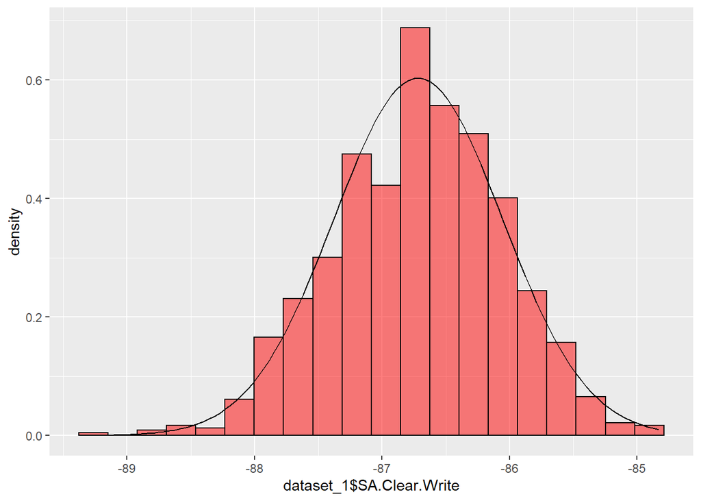

```r
ggplot(dataset_1) +
      aes(x=dataset_1$SA.Clear.Write) +
      geom_histogram(fill="red",
                     col="black",
                     alpha = 0.5,
                     bins=20,
                     aes(y=..density..)) +
stat_function(fun = dnorm, args=list(mean(dataset_1$SA.Clear.Write), sd=sd(dataset_1$SA.Clear.Write)))
```

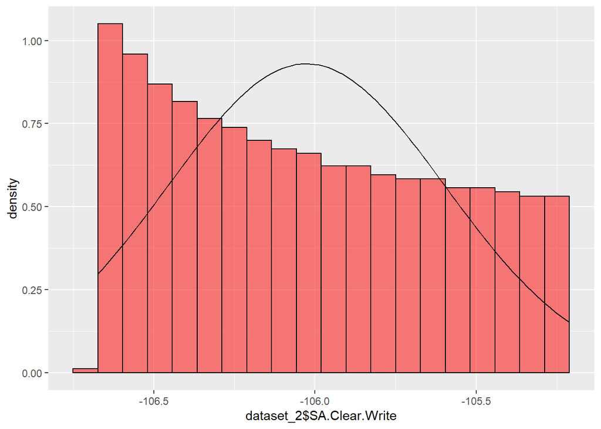

```r
ggplot(dataset_2) +
      aes(x=dataset_2$SA.Clear.Write) +
      geom_histogram(fill="red",
                     col="black",
                     alpha = 0.5,
                     bins=20,
                     aes(y=..density..)) +
stat_function(fun = dnorm, args=list(mean(dataset_2$SA.Clear.Write), sd=sd(dataset_2$SA.Clear.Write)))
```

> 4. Em qual localidade específica foram realizadas as medições de cada conjunto de dados? Dataset 1 (22 15.40727 S, 45 41.74932 W) Santa rita do sapucai Campos do inatel(Prédio II) Dataset 2 (22 15.382499 S, 45 41.758792 W) Santa rita do Sapucai campos do Inatel(Rua Próximo as antenas)

## Exercício Computacional - 4

Conceito explorado: Estatística Descritiva e Análise Exploratória de Dados Considere o mesmo contexto do exercício anterior e um conjunto maior de arquivos .csv, que são exportados pelo instrumento de medida e armazenados em um diretório.

> 1. Com os arquivos .csv armazenados no diretório, elabore uma rotina em linguagem R para fazer a leitura de todos os arquivos de forma otimizada.

```r
#setwd(dirname(rstudioapi::getActiveDocumentContext()$path))
#data_dir <- paste(dirname(rstudioapi::getActiveDocumentContext()$path), "/Datasets", sep ="")
#str(data_dir)

data_dir <- 'Datasets//'


filesNames <- list.files(data_dir)
headers <- c("Data Freq","SA Clear-Write","SA Blank","SA Blank","SA Blank")

df_list <- list()
i <- 1
for(p in filesNames) {
    csvPath = paste("Datasets//", p, sep="")
    str(csvPath)
    p <- read.csv(csvPath, sep=",", header=F, comment.char="!", col.names = headers) %>% na.exclude()
    df_list[[i]] <- p
    i <- i + 1
}
```

```
##  chr "Datasets//dataset_1.csv"
##  chr "Datasets//dataset_10.csv"
##  chr "Datasets//dataset_2.csv"
##  chr "Datasets//dataset_3.csv"
##  chr "Datasets//dataset_4.csv"
##  chr "Datasets//dataset_5.csv"
##  chr "Datasets//dataset_6.csv"
##  chr "Datasets//dataset_7.csv"
##  chr "Datasets//dataset_8.csv"
##  chr "Datasets//dataset_9.csv"
```

Leio todos os arquivos da pasta Datasets, tranformo cada arquivo em um novo dataframe e adiciono esse dataframe a uma lista de dataframes.

> 2. Capture os dados de geolocalização (latitude, longitude) de todos os arquivos, faça os processamentos e transformações necessárias, visando o armazenamento em um dataframe.

```r
data_dir <- "Datasets//" # paste(dirname(rstudioapi::getActiveDocumentContext()$path), "/Datasets", sep ="")
filesNames <- list.files(data_dir)


latList <- list()
longList <- list()
files <- list()

df_medidas <- data.frame("df"=character(),
                         "lat"=character(),
                         "long"=character(),
                         "lat_long"=numeric(),
                         "long_long"=numeric())

for(p in filesNames) {
    csvPath = paste("Datasets/", p, sep="")
    str(csvPath)
    lines <- readLines(csvPath)

    lat <- lines[13] %>% substring(17)
    long <- lines[14] %>% substring(18)


    lat_chd = paste(substr(lat,1,2), sep="", "d")
    lat_chm = paste(substr(lat,4,5), sep="", "'")
    lat_chs = paste(as.character(as.numeric(substr(lat,6,11)) * 60), sep="", "\"")
    lat_ns = substr(lat,(nchar(lat)+1)-1,nchar(lat))

    long_chd = paste(substr(long,1,2), sep="", "d")
    long_chm = paste(substr(long,4,5), sep="", "'")
    long_chs = paste(as.character(as.numeric(substr(long,6,11)) * 60), sep="", "\"")
    long_ew = substr(long,(nchar(long)+1)-1,nchar(long))

    lat_long <- sprintf("%s%s%s%s", lat_chd, lat_chm, lat_chs, lat_ns)
    long_long <- sprintf("%s%s%s%s", long_chd, long_chm, long_chs, long_ew)
    lat_long <- as.numeric(char2dms(lat_long))
    long_long <- as.numeric(char2dms(long_long))
    r <- data.frame(p, lat, long, lat_long, long_long)

    df_medidas <- rbind(df_medidas, r)

}
```

```
##  chr "Datasets/dataset_1.csv"
##  chr "Datasets/dataset_10.csv"
##  chr "Datasets/dataset_2.csv"
##  chr "Datasets/dataset_3.csv"
##  chr "Datasets/dataset_4.csv"
##  chr "Datasets/dataset_5.csv"
##  chr "Datasets/dataset_6.csv"
##  chr "Datasets/dataset_7.csv"
##  chr "Datasets/dataset_8.csv"
##  chr "Datasets/dataset_9.csv"
```

```r
head(df_medidas)
```

|  | p | lat | long | lat_long | long_long |
| --- | --- | --- | --- | --- | --- |
| 1 | dataset_1.csv | 22 15.40727 S | 45 41.74932 W | -22.25679 | -45.69582 |
| 2 | dataset_10.csv | 22 15.502499 S | 45 41.748792 W | -22.25837 | -45.69581 |
| 3 | dataset_2.csv | 22 15.382499 S | 45 41.758792 W | -22.25637 | -45.69598 |
| 4 | dataset_3.csv | 22 15.47427 S | 45 41.73954 W | -22.25790 | -45.69566 |
| 5 | dataset_4.csv | 22 15.4327 S | 45 41.7711 W | -22.25721 | -45.69618 |
| 6 | dataset_5.csv | 22 15.43827 S | 45 41.7211 W | -22.25730 | -45.69535 |

> 3. Apresente no mapa os dados de geolocalização obtidos no item anterior.

```r
m <- leaflet() %>%
  addTiles() %>%
  addMarkers(df_medidas, popup="antena", lng = df_medidas$long_long, lat = df_medidas$lat_long)
m  # Print the map
```

[interactive chart not shown]

## 5. Exercício Computacional - 5

Conceito explorado: MSE - Mean Square Error Considere o seguinte modelo de geração de dados mostrado abaixo: y = h(x) +ε (1.3) Nesse modelo, h(x) = 3x+30 consiste na função hipótese verdadeira, muitas vezes desconhecida na prática de ML, e ε é um termo que expressa a incerteza entre os valores da função hipótese verdadeira e a variável de saída ou resposta y. Estatisticamente, ε é interpretado como um ruído, que nesse exercício segue a distribuição de probabilidade Gaussiana com média µ = 0 e desvio padrão σ = 15. A notação em negrito usada ocorre em função de (1.3) ser um modelo vetorial de dados. A variável explanatória x usada será um vetor de valores inteiros de zero (1) a cem (100). Logo, o modelo de dados é formado pelos vetores y, h(x) e ε, sendo cada um com dimensões (número de linhas e colunas) de 100×1. Considere que um grupo de cientistas de dados já realizaram o trabalho de modelagem e encontraram uma função hipótese candidata dada por: hˆ(x) = 2.8x+32 (1.4) > 1) Construa esse modelo de geração de dados. Para que seja possível a reprodução de resultados em função do vetor aleatório ε utilize a semente (seed) 123 em seu código.

```r
set.seed(123)
seq_x = 1:100
func_h_x <- 3*seq_x + 30
e <- rnorm(n = 100, mean = 0, sd = 15)

out_y <- func_h_x + e
```

> 2. Faça um gráfico de dispersão da variável explanatória x com saída conhecida y.

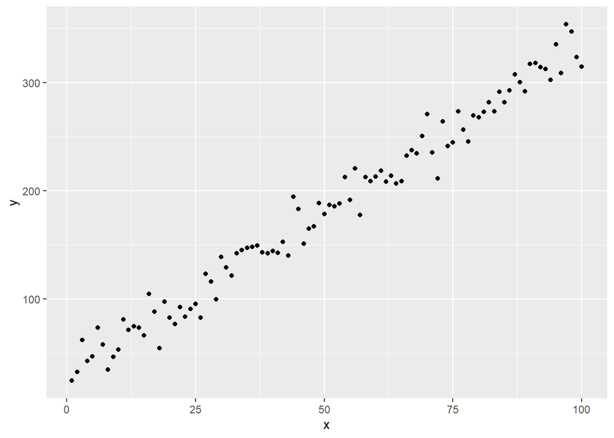

```r
library(ggplot2)
df_x_y = data.frame(x=seq_x, y=out_y)
ggplot(df_x_y, aes(x=x, y=y), title("Grafico de dispersão")) + geom_point()
```

> 3. Obtenha o histograma relacionado com a variável de saída y.

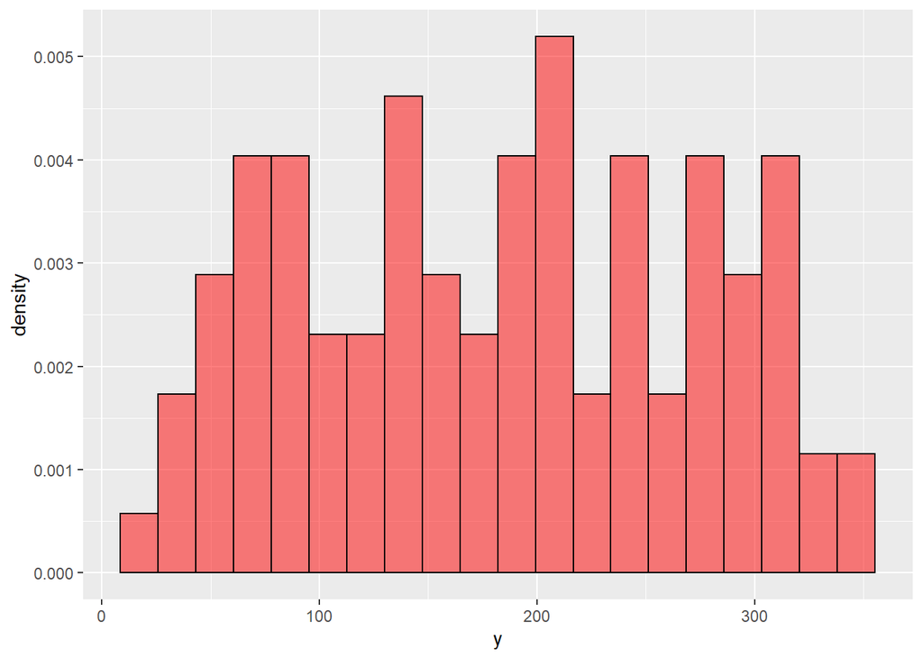

```r
ggplot(df_x_y) +
      aes(x=y) +
      geom_histogram(fill="red",
                     col="black",
                     alpha = 0.5,
                     bins=20,
                     aes(y=..density..))
```

> 4. A equação do MSE, mostrada abaixo, é uma métrica de desempenho relacionada com qual tipo de tarefa de aprendizagem de máquina? MSE = 1 N N ∑ i=1 (yi −hˆ(xi))2 (1.5)

Aprendizagem supervisionada.

> 5. Faça a estimação do erro quadrático médio do modelo proposto pelos cientistas.

```r
h_x_estimado <- 2.8*seq_x + 32
#h_x_estimado
MSE = (1/100)*sum(((out_y - h_x_estimado)^2))
MSE
```

```
## [1] 320.9044
```

> 6. Faça uma análise: o modelo proposto é plausível para explicar os dados? De quais fatores esse desempenho depende?

O modelo proposto é plausivel para explicar os dados, seu desempenho depende de outros fatores como x, ruido e variancia.

## 6. Exercício Computacional - 6

Conceito explorado: MSE - Mean Square Error Considere o mesmo modelo de geração de dados do exercício anterior. O objetivo aqui é constatar o impacto do desvio padrão σ sobre a performance do modelo proposto pelos cientistas de dados. Para isso, utilize a instrução abaixo, em linguagem R, para a geração de um vetor com diversos valores de desvio padrão para a incerteza Gaussiana retratada pelo termo ε. Para que seja possível explorar e visualizar o impacto de σ - realize, pelo menos, 1000 iterações do algoritmo. Especificamente, para cada valor de desvio padrão avaliado, armazene e faça o cálculo da média aritmética sobre 1000 valores de performance expressos pelo MSE. Um dica é utilizar estruturas em loop (for) para a implementação das iterações. > 1) Construa o modelo de geração de dados incluindo as iterações para cada valor de σ

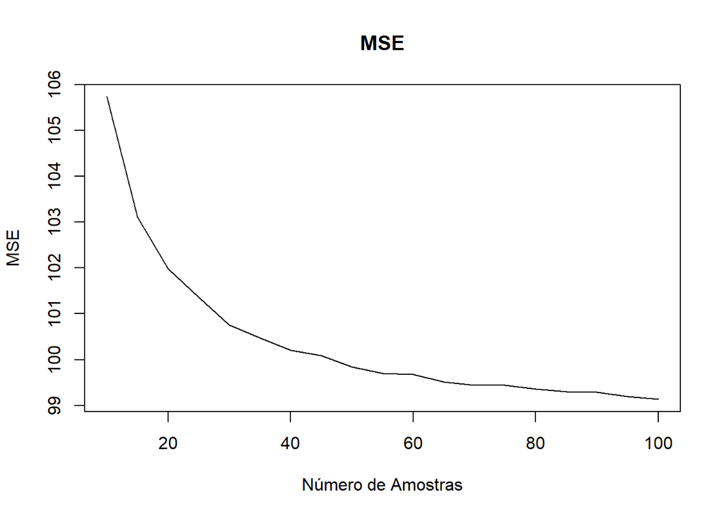

```r
# Número de iterações para cálculo do MSE
num_iter = 1000
# std_vector = seq(1,10,1)
# Vetor com valores de número de amostras
n_vector = seq(10,100,5)
# Inicialização dos vetores de MSE
MSE_vector = rep(0,length(n_vector))
MSE        = rep(0,num_iter)
for (k in 1:length(n_vector)){
  n = n_vector[k]
  x = seq(1, 100, length.out = n)
  h_x <- 3*x + 30

  for (i in 1:num_iter){
    std = 0.5
    epsilon <- rnorm(n, 0, std)

    y <- h_x + epsilon

    h_x_estimado <- 2.8*x + 32

    MSE[i] = (1/n)*sum(((y - h_x_estimado)^2))
  }

  MSE_vector[k] = mean(MSE)
}

plot(n_vector,MSE_vector,col=1, pch=1, main = 'MSE',
     col.main = 'black',
     xlab = 'Número de Amostras',
     type="line",
     ylab = 'MSE')
```

[output not shown]

```r
mse_data = data.frame(n_vector,MSE_vector)
```

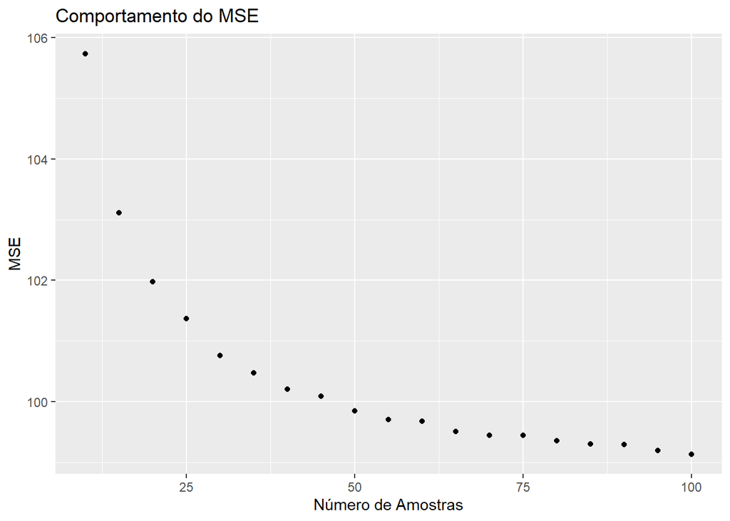

```r
# Uso do pipe (tidyverse) e ggplot2
mse_data %>% ggplot(aes(x = n_vector, y = MSE_vector)) +
  geom_point() +
  xlab('Número de Amostras') +
  ylab('MSE') +
  ggtitle('Comportamento do MSE')
```

[output not shown]